# Presentación

2025-12-26

## Objetivos del Proyecto

El objetivo general es examinar cómo las percepciones sociales se relacionan con los patrones de consumo digital en Europa (ESS Ronda 11, 2023).

Objetivos específicos:

Visualizar la distribución geográfica de la confianza interpersonal.

Evaluar si el consumo de noticias (Internet vs. Tradicional) se asocia con la confianza.

Comparar perfiles de países según intensidad de uso de Internet.

## Estadísticos descriptivos (Tabla 1)

A continuación, un resumen de las variables principales analizadas:

Medias y tiempos de uso

| N | Trust | Justice | Help | Net(min) | News(min) | Net(h) | News(h) |
| --- | --- | --- | --- | --- | --- | --- | --- |
| 38489 | 5.34 | 6.03 | 5.27 | 237.21 | 91.4 | 3.95 | 1.52 |

## Análisis de Descriptivos:

Variables Sociales: Todas superan el punto medio. Destaca Justicia (6.03) como la más alta, seguida de Confianza (5.34).

Consumo de Medios: Predominio digital. El uso de Internet (3.95h) duplica ampliamente al de Noticias Tradicionales (1.52h).

## Correlaciones (Tabla 2)

¿Influye el tiempo de consumo en la confianza?

Correlaciones de Pearson (vs. Confianza)

| r (Net-Trust) | N | r (News-Trust) | N |
| --- | --- | --- | --- |
| 0.014 | 38489 | -0.009 | 38489 |

## Análisis de Relación

Impacto Nulo: La cantidad de tiempo consumido no tiene impacto significativo.Coeficientes: Internet muestra una relación marginal positiva (\(r = 0.014\)) y las noticias una negativa (\(r = -0.009\)), ambas prácticamente inexistentes.Conclusión: La duración de la exposición no determina la confianza interpersonal.

## Mapa de Confianza Interpersonal

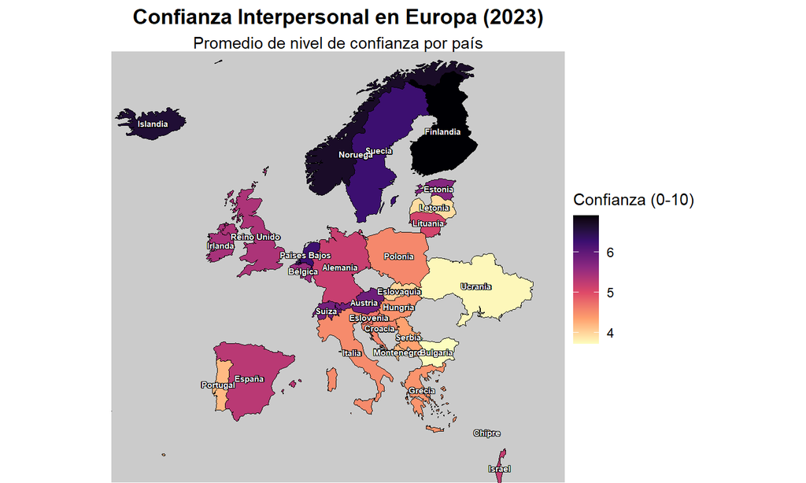

## Hallazgos: Distribución Geográfica

El mapa revela un patrón geográfico Norte-Sur y Este:

Alta Confianza: Los países nórdicos (Finlandia, Islandia, Suecia) muestran las puntuaciones más elevadas (tonos oscuros).

Confianza Media: Europa Occidental (Alemania, Suiza, Países Bajos).

Baja Confianza: Países del sur y este (Grecia, Polonia, Balcanes) presentan tonos claros, indicando menor confianza interpersonal.

## Correlación: Consumo vs. Confianza

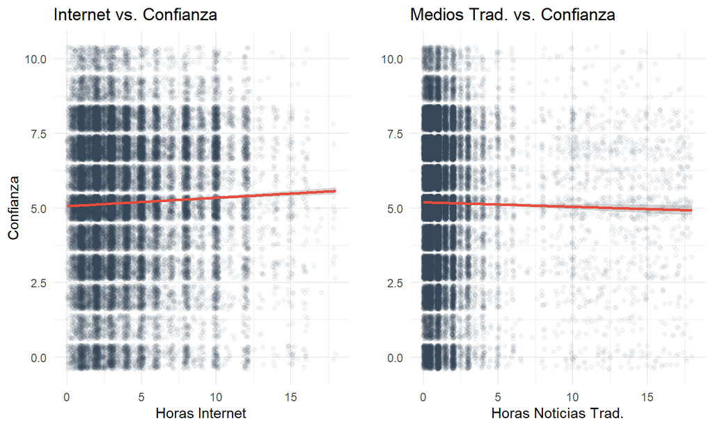

## Hallazgos: Diagramas de Dispersión

Las relaciones encontradas son débiles pero opuestas:

Internet: Tendencia marginalmente positiva. Mayor uso de Internet se asocia levemente con mayor confianza.

Noticias Tradicionales: Tendencia levemente negativa. Mayor consumo de TV/radio se asocia con menor confianza.

Dispersión: La gran “nube” de puntos indica que el tiempo de consumo no es un predictor determinante de la confianza; existen otros factores sociales más relevantes.

## Perfiles de Consumo (Gráfico Mariposa)

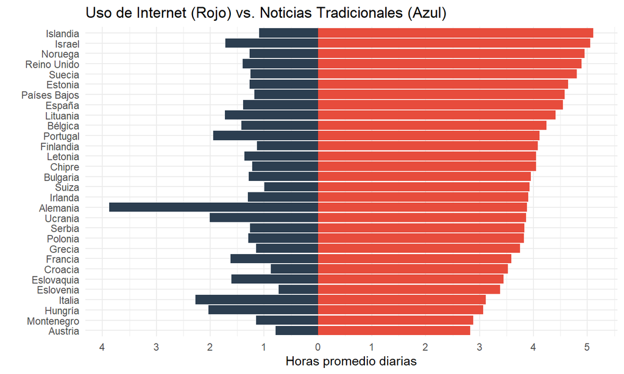

## Hallazgos: Brecha Digital

Asimetría: El uso de Internet (derecha, rojo) supera significativamente a los medios tradicionales (izquierda, azul) en casi todos los países.